# Publishing analyses + Peer code review

Reproducing analyses from a persistant project repository

Author

Affiliation

Daniela Palleschi

Humboldt-Universität zu Berlin

Published

June 24, 2024

# Learning objectives

Today we will…

- set-up our first OSF project
- share necessary files to make our OSF project reproducible
- conduct a code review of our own project
- conduct a peer code review

# Resources

- DeBruine (2022) and accompanying [slides](https://debruine.github.io/code-review/#/title-slide)

# 1 Open and FAIR data

- recall the FAIR principles we discussed at the beginning of term
  - data should be Findable, Accessible, Interoperable, and Reusable
  - we’re extending these principles to our *analyses* as well
- so far, our data and analyses are stored locally on our machines
  - we need to share them with persistent public storage
  - e.g., GitHub or GitLab, the Open Science Framework (OSF) or Zenodo

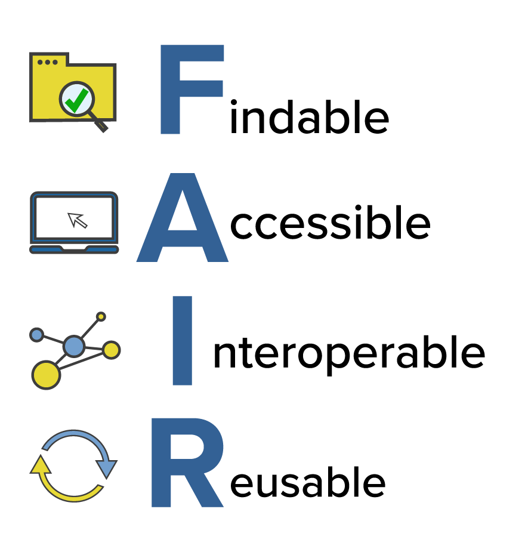

Figure 1: Source: [National Library of Medicine](https://www.nlm.nih.gov/oet/ed/cde/tutorial/02-300.html) (all rights reserved)

# 2 OSF: Open Science Framework

- we’ll use the OSF (https://osf.io/), which is a user-friendly project management platform
  - provides persistant URLs
  - user-friendly (drag-and-drop)
  - popular for open storage of data, materials, and analyses
- also offers pre-registration and pre-print storage
- can also be connected to Dropbox, Google Drive, GitHub and GitLab
  - but this requires you to have your data and analyses stored on these services, the security of which cannot be guaranteed long-term
- if you don’t already have an OSF account, click the ‘sign up’ button at the top right of the [OSF homepage](https://osf.io/)

# 3 Our first OSF repo

- we’ll start by creating a new OSF project
1. Sign in to the OSF
2. Click on ‘Create new project’
   - provide a name such as ‘Open Science Practices: Reproducibility coursework (SoSe2024)’
   - **Important**: set storage location to `Germany - Frankfurt`
   - add some concise description
3. Navigate to your project and explore the page and tabs

## 3.1 Private or public

- you should notice near the top right corner a button ‘Make Public’
  - this tells you that your project is currently private
  - this means nobody can see it but you (or any collaborators you add)
- typically you would make a repository public when it has been accepted for publication, or if you publish a pre-print
  - you can also make it public before this, but this is something to discuss with your collaborators

## 3.2 Contributors

- repository contributors are typically co-authors or collaborators for a project
- click on the ‘Contributors’ tab (top right of the screen)
  - click on ‘+ Add’, find my account, and add me as a collaborator with ‘Read’ rights
  - make sure the ‘Bibliographic Contributor’ button is checked
  - this just means that I will be included as bibliographic author if this repo is ever cited
- go back to the project page, do you see any changes?

## 3.3 Adding files

- our purpose for creating an OSF project was to share our data and materials
  - to do this, we navigate to the ‘Files’ tab
- rather unfortunately, we can only upload files (i.e., not entire folders)
  - this has the benefit of meaning our folder structure must be *intentional*
  - but the drawback that it’s quite tedious if you want to share a large project
- let’s start by adding our data and scripts
  - add a folder called `data`
  - and another folder called `scripts` or `code`, or whatever you prefer

## 3.4 Adding data

- under `data`, add the three `csv` files you presumably have in the same folder in your project (drag and drop them, or select the big green `+`)
  - `data_lifetime_pilot.csv`
  - `tidy_data_lifetime_pilot.csv`
  - `tidy_data_lifetime_pilot_dictionary.csv`

## 3.5 Adding scripts

- under the `scripts` folder add the scripts where we worked with the data:
  - our wrangling script
  - our tables script
  - our data visualisation script

### 3.5.1 Adding PDF output

- optionally, you can also upload the PDF output produced by each script
  - this means that anybody viewing your project doesn’t have to download the Quarto scripts to see what was done (as they aren’t viewable in-browser)

### 3.5.2 Structuring your `scripts/` folder

- unlike the `data` folder, how you organise and name this folder on OSF is more flexible
  - because we (likely) aren’t accessing these scripts from somewhere else in the project (unlike loading data from the `data` folder)
- you can include them in sub-folders if you prefer
  - the structure of this folder is organisational, and not fundamental to reproducibility
  - more organised folders make it easier to navigate for someone not familiar with the project structure
  - keeping this structure identical to your actual project structure is also ideal for on-going larger projects, but it’s up to you

**Checklist: Share data and code**

At this point, your OSF project should

- be private (this is the default for a new project)
- have me as a collaborator
- contain the folders `data/` and `scripts/`
  - which in turn contain the 3 `CSV` files and 3 Quarto scripts
  - ideally `scripts/` will also contain the 3 PDF script outputs

# 4 Checking reproducibility

- a code review refers to when somebody else checks your code
  - this should also include a check for reproducibility
  - as well as validity and good coding practices (not our focus right now)
- why should we do it?
  - firstly, everybody makes mistakes! increases the chances they’ll be fixed
  - tests reproducibility
- let’s do a quick code review of our own OSF repos, checking to see if we can download and re-run our own analyses

## 4.1 Download OSF repo

- let’s start by downloading our OSF repo
  - from the project overview page, go to the ‘Files’ pane
  - click on ‘OSF Storage (Germany - Frankfurt)’
  - Click ‘Download as zip’ button and store somewhere useful/rename as needed

[figure not shown]

Figure 2: How to download an OSF repo

## 4.2 Reproduce your analyses

- first, close all R projects you currently have open
  - this is because RStudio might try to open your downloaded scripts in an already open RProject, which we don’t want
- now, navigate to the zip you just downloaded and decompress it (double-click)
  - select a Quarto script from `scripts/`
  - try to run the script, does it run?
  - probably not…let’s discuss why

# 5 Revisiting reproducibility

- we’ve shared the code, not just the data
  - this has been strongly encouraged in the reproducibility research as of late (e.g., the title *Share the code, not just the data…*, Laurinavichyute et al. (2017))
  - but is this sufficient to ensure long-term reproducibility?
  - Laurinavichyute et al. (2017) (among others) suggest many more steps that should be taken to improve reproducibility
- our focus is on sharing data and analyses with the aim of reproducibility, not just documenting what was done
  - so we have to share what is necessary to make our project reproducible
  - e.g., that it can be run with the same environment on another machine?
- so what should we share?

## 5.1 Improving code reproducibility

- what structural dependecies do our scripts have?
  - e.g., filepaths and folder names
- consider, for example, how we accessed the data from our scripts
  - did we use `setwd()`?
  - did we use filepaths?
  - no, we used the `here()` package within an R project
  - this meant we used our project root directory as our working directory
- so, we should, at minimum, also include the `.Rproj` file at the project root directory

## 5.2 Reproducibility spectrum

- reproducibility is on a continuum, referred to as the *reproducibility spectrum* in Peng (2011) (Figure 3)
  - *linked* means “*all data, metadata, and code [is] stored and linked with each other and with corresponding publications*” (Peng, 2011, p. 1227)
  - *executable* is not explained, and is more difficult to guarantee long-term as it depends on software versions
  - but at minimum we can assume it refers to code running on someone else’s machine

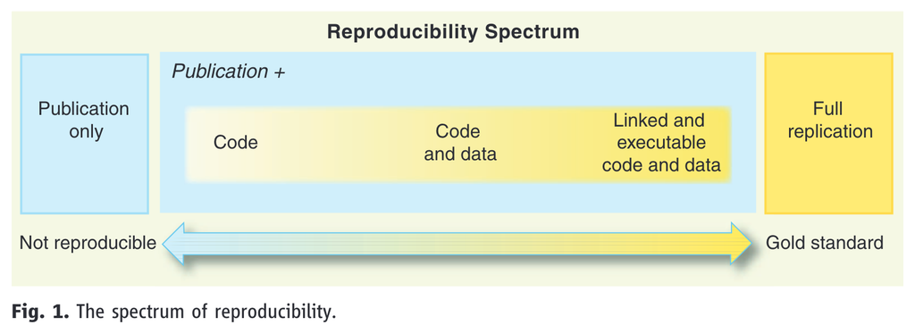

Figure 3: Source: Peng (2011)

## 5.3 Reproducibility iceberg

- a more detailed description of this continuum is givin in Rodrigues (2023)’s *reproducibility iceberg* (Figure 4)
  - our project is currently somewhere near the top-middle of the iceberg
  - we’re not using GitHub, with is a developer platform and useful for version control and is beyond the scope of this course
    - GitHub and OSF serve some overlapping, but not identical, purposes
- importantly, the iceberg explicitly mentioned the `renv` package
  - this reminds us that we should be *sharing* some files generating by `renv`

[figure not shown]

Figure 4: Source: Rodrigues (2023)

## 5.4 Packages

**Checklist: Share `renv.lock`**

Add the `renv.lock` file to your OSF project repo (in the project root directory).

## 5.5 Auto-loaders

- we also need to include our `.Rprofile` file
  - this is our auto-loader
  - whenever we open the R project, this file will be run
- it currently contains just `source("renv/activate.R")`
  - this means: when you open the R project, run the `renv/activate.R` file
- so, we need to include our `renv/activate.R` file in our OSF repo
  - including these two will automatically install the relevant version of `renv`

**`.Rprofile` in Finder**

Some files are usually invisible on a Mac, such as those that start with dot (like `.Rprofile`). This makes it difficult to simply drag and drop the `.Rprofile` file to the OSF. To make such files viewable in Finder, navigate to the relevant project folder and use the keyboard shortcut `Ctrl + Shift + Dot`. These files will then appear greyed out.

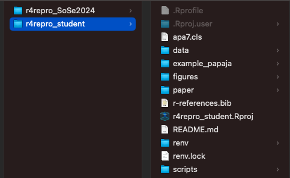

Figure 5: Use the shortcut `Ctrl + Shift + Dot` to view hidden files on a Mac

## 5.6 README

- remember to update your README accordingly!
  - this can be updated as you add more to your project
- the project `README.md` will ideally have information that is useful once the project is downloaded in its entirety
  - e.g., brief info about the project/data
  - description of the folder/file structure
  - any info required for reproducibility
- e.g., anybody who downloads the project will need to run `renv::restore()` to restore your project library (but this will only work if they’re using the same R version!)
  - so be sure to include that info!

For example, you could add something like this:

```markdown
**Reproduce analyses**: Once you open this project, `renv` will automatically be installed. After this is complete, you please run `renv::restore()` to restore the project package library. This will not affect the package versions you have already installed globally on your machine.
```

**Checklist: Share `.Rprofile` and `renv/activate.R`**

Your project should now have

- `.Rprofile` in the project root directory
- `renv/activate.R` in the project root directory
  - i.e., a folder `renv/` in the root directory
  - and the `activate.R` file in this `renv/` folder
- a `README.md` file in the root directory

## 5.7 OSF repo structure

- your OSF project should look something like Figure 6
  - N.B., there are more files under `scripts/`

[figure not shown]

Figure 6: Your OSF should now look like this

# 6 Code review

- we’ll again try to reproduce our own analyses before sharing the OSF project with a peer
- again, close all R projects you currently have open
- now, navigate to the zip you just downloaded
  - select a Quarto script from `scripts/`
  - try to run the script, does it run?

## 6.1 Sharing your project

- we need to share our project with others
  - your project is still private
  - so you need to produce a link because the URL won’t work for non-contributors
- produce a View-only link
  - you can do this in Settings (top right)
  - give an informative name (so you remember why you created this link)
- if you select `Anonymize`, your name will be removed from the project
  - this is useful for e.g., blind peer review
  - but will *not* remove your name from your scripts!

## 6.2 Swapping project URLs

- go to Moodle and add your OSF repo URL
- go to someone else’s OSF repo and download their project
  - inspect the project metafiles (e.g., README)
  - try to reproduce the analyses, can you?

**Anonymising your scripts (optional)**

If you have a relatively large project with your name at the beginning of multiple scripts, it can be tedious to manually remove it. And you might not be sure you actually took your name out of everything!

This can be used using RStudio’s [Global Find](https://posit.co/blog/rstudio-1-3-the-little-things/):

- press `Cmd+Shift+F`
- in the pop-up, choose your filepath (for me: the OSF folder *only*) and hit enter
- then toggle to ‘Replace’ when a tab pops up next to the Terminal
- type in your replacement (e.g., `[Anonymized for peer review]`), and hit “Replace All”

**Important**: this will work for HTML and R/Quarto/Rmd scripts, but *not* for PDFs! so you might want to re-render all PDFs. As far as I can tell you have to re-render each PDF. If you’re working in a Quarto project (and not an `.Rproj`), then you can use `quarto render subfoldername --to pdf` in the Terminal to re-render only the OSF PDFs. We didn’t discuss Quarto projects in this course, however.

After the manuscript is accepted, you can then reverse this step: use the Global Find to replace `[Anonymized for peer review]` with your name! This is why I suggest surrounding the phrase with `[]`, it ensures you don’t accidentally replace the string ‘anonymized for peer review’ elsewhere in your files (e.g., maybe you wrote in some analysis plan “all scripts will be anonymized for peer review”, which would then be changed to “all scripts will be Daniela Palleschi” if I had replaced `Anonymized for peer review` with my name).

# 7 Quiz 2: Code Review Q&A

- there is a Code Review Q&A on Moodle, which *counts towards course credit*
  - consists of mostly true/false questions about your code review
- do this quiz by next week
  - nobody is penalised if the code isn’t reproducible
- the point is to learn how to do a code review and how to improve our own projects to improve reproducibility

# Learning objectives 🏁

Today we…

- set-up our first OSF projectc ✅
- shared necessary files to make our OSF project reproducible ✅
- conducted a code review of our own project ✅
- conducted a peer code review ✅

# References

DeBruine, L. (2022). *Intro to code review*. https://debruine.github.io/code-review/

Laurinavichyute, A., Yadav, H., & Vasishth, S. (2017). Share the code, not just the data: A case study of the reproducibility of JML articles published under the open data policy. *Preprint*, 1–77.

Peng, R. D. (2011). Reproducible Research in Computational Science. *Science*, *334*(6060), 1226–1227. https://doi.org/10.1126/science.1213847

Rodrigues, B. (2023). *Building reproducible analytical pipelines with R*.